# Teach Yourself R Tutorial #1

## Tangent: How to read a help page

Check out the **syntax** for the `matrix()` function, or any other function, by typing a `?` and then the name of the function.

```r
?matrix
```

**Description** gives a brief description of what a function does.

**Usage** provides the syntax. Note that by default, `data = NA`, `nrow = 1`, `ncol = 1`, and `byrow = FALSE`.

```r
## If you type in matrix() with no arguments, you get a 1-by-1 matrix containing NA
matrix()

## If you specify byrow = T, you can populate the matrix by row instead of by column
people
matrix(people, 2, 2)
matrix(people, 2, 2, TRUE)
```

**Arguments** are the things you put inside the parenteses when you call a function. On the help page, it tells you what you are allowed to pass as **input**. Note that when you leave out the names of **arguments** when you are calling the function `matrix`, R knows what you are telling it to do based on the order of the **arguments**. If you want to give the **arguments** of the function out of order, you have to specify their names.

**Details** tells you additional information you might need to understand what a function is doing.

## Manipulating data

Sometimes, you might want to figure out where a value is in your matrix, or just pull out certain parts of the matrix that match a given value. You can do this with a logical, or with the `which()` command.

```r
# You can make matrices of characters or logicals as well
ppl.matrix <- matrix(people, 2, 2)
ppl.matrix
is.brian <- matrix(people == "Brian", 2, 2)
is.brian

# When you pass a logical to a matrix or vector of the same length, R returns the values for which the input was TRUE
ppl.matrix[is.brian]

# You can do the same with a vector
digits
digits == 9
digits[digits == 9]

# Or you can use the which() command to store the indices for which the logical expression is TRUE
which(digits == 1)
i <- which(digits == 1)
j <- which(digits > 1)
digits
digits[i]
digits[j]
```

The **`rownames()`** and **`colnames`** can be used to assign names to columns and rows of a matrix. Instead of using numbers or the which command you can also call columns and rows by their names.

```r
colnames(ppl.matrix)<-c('Teenagers', 'Adults')
ppl.matrix
```

```
##      Teenagers Adults
## [1,] "Brian"   "Lynne"
## [2,] "Evan"    "Geoff"
```

```r
# Call the column of grownups
ppl.matrix[, "Adults"]
```

```
## [1] "Lynne" "Geoff"
```

### Matrix Excercise (10 min)

> Create a 2-by-3 matrix with a *new* name and populate it row by row with the vector `digits` we created earlier.

> Create another 2-by-3 matrix with a *different* name and populate it column by column with the values of `digits`.

> Use the `which()` command to find the index of the value `5` in each of your new matrices.

> Question: What does which() return for matrices? Compare results from each matrix (by row and column). Use `?which` if needed. (Hint: a matrix is a special, 2-dimensional case of an array)

```r
which(ppl.matrix=="Geoff")
```

```
## [1] 4
```

```r
which(ppl.matrix=="Geoff", arr.ind=T)
```

```
##      row col
## [1,]   2   2
```

```r
ppl.matrix
```

```
##      Teenagers Adults
## [1,] "Brian"   "Lynne"
## [2,] "Evan"    "Geoff"
```

**Lists** are a totally different type of object where you can basically put lots of different things together, with names, in order. Unlike vectors, matrices, etc. each element of a list can be a completely different type of object, including matrices, vectors, functions, or any type of object you want. To create access the nth element in a list, you can: + use the `$` operator followed by its name. + use double brackets (`[[]]`) with the name or index number of the element inside

> `Name.of.list.object$Name.of.element <- Value`

> `Name.of.list.object[['Name.of.element']] <- Value`

> `Name.of.list.obnject[[n]]`

Note that if you are adding things to a list without an order, the operators above will add each new element

```r
All.the.stuff <- list()
All.the.stuff$digs <- digits
All.the.stuff[['ppl']]  <- people
All.the.stuff$ppl.mat <- ppl.matrix

# You can even put a function in a list
All.the.stuff$f <- colnames

All.the.stuff$ppl.mat
All.the.stuff$ppl
All.the.stuff$f
```

Note that when you type in the name of a function object, R outputs the code! This can be very useful.

**Data Frames** are essentially a hybrid between a matrix and a special case of lists. Each column of a data frame can be a different type of data (i.e., `character`, `logical`, `numeric`) but they all have to be the amse length. You call a column or create a new column with its name after the `$` or its name or number inside single brackets `[,'name']`. You can create a data frame with the `data.frame()` function. Type `?data.frame` to see what type of arguments to give it.

```r
# Create a new dataframe
new.one <- data.frame(ppl = people, numbers = digits[1:4])
new.one
new.one$numbers

# Add a new column
new.one$lastname <- c("Rago", "Rago", "Frederickson", "Williams")
new.one$job <- c("College", "Highschool", "Real job", "Grad student")
new.one
```

## More functions

**`paste()`** Strings things together, separated by whatever you specify in the `sep` argument (default is a whitespace, or `sep = " "`). Type `?paste` to see what type of arguments to give it. Note that in the documentation pages for both `data.frame()` and `paste()` the **Usage** area includes an ellipse `...` as the first argument. If you read **Arguments** you will see that you can provide an unlimited number of character objects to the `paste()` followed by `sep`.

```r
paste(new.one$ppl[1], new.one$ppl[2], new.one$ppl[3])
```

```
## [1] "Brian Evan Lynne"
```

```r
paste(new.one$ppl[1], new.one$ppl[2], new.one$ppl[3], sep = " and ")
```

```
## [1] "Brian and Evan and Lynne"
```

```r
# The 'collapse' argument allows you to give a vector
paste(new.one$ppl[1:3], collapse=" and ")
```

```
## [1] "Brian and Evan and Lynne"
```

```r
paste(new.one$ppl, collapse=" and ")
```

```
## [1] "Brian and Evan and Lynne and Geoff"
```

**`readline()`** Takes use input, and its output can be redirected into an object with `<-` like any other function. Try putting a number, and then try putting a character, into new.one$numbers, and then check it with the `class()` function to see what type of data type. *How does R deal with code that sticks a character in a numeric object?*

```r
## new.one$numbers is a numeric
class(new.one$numbers)

## enter a number as input on the command prompt and see what happened
new.one$numbers[1] <- readline()
new.one
class(new.one$numbers)

## now do the same thing but enter a character
new.one$numbers[1] <- readline()
new.one
class(new.one$numbers)
```

**`grep()`** Is fun because it can search for different types of strings or other values.

```r
new.one
grep("Rago", new.one$lastname)
grep("Rago", new.one$lastname)

# If you give it a matrix or data frame, grep returns the number of the matching
columns <- grep("ll", new.one)
new.one[,columns]
rows <- grep("ll", new.one[,columns[1]])
new.one[rows, columns[1]]
rows2 <- grep("ll", new.one[,columns[2]])
new.one[rows2, columns[2]]
```

### Function Excercise 1 (10 min)

> Read in three characters using `readline()` into three separate objects called `subj`, `verb`, and `obj`.

> Put subj, verb, and obj together in a vector of length 3 called `words`.

> String them together with `paste()` to make a sentence, and store that in a new object `sent`.

> Use `grep()` to find a pattern in common between multiple elements in `words`.

## Reading in data

The **`read.csv()`** function is useful. First check that you are in the right drive, and if not, navigate to the proper directory where you have stored the files for the workshop. You can scroll down to Session > Set Working Directory or use `getwd()` and `setwd()` on the command line to see what directory R is working in, and change the directory if necessary.

```r
getwd()
setwd("/Users/will1809/OneDrive - purdue.edu/TCD microbiome spring 2017/Aaron Manuscript/Geoff_Final_RFiles/Juglans.microbiome.github/readingradio.github.io/RWorkshop")
beetles <- read.csv("WillGinzEnvEnt2019.Fall.csv")
```

**`head()`** Looks at just the first six, or a different number of rows specified by `n=`.

**`names()`** returns the same thing as `colnames()`.

**`sum()`** sums everything in a vector or matrix up.

**`rowSums()`** returns a vector containing row sums.

**`summary()`** computes a nice summary of each column in a data frame.

```r
head(beetles)
```

```
##                   Species       family X2013 X2014 X2015 X2016 X2017 X2018
## 1    Aegomorphus modestus Cerambycidae     0     3     3     3     1     0
## 2  Cyrtophorus verrucosus Cerambycidae     0     0     0     3    11     1
## 3    Gaurotes cyanipennis Cerambycidae     0     0     1     1     9     2
## 4        Knulliana cincta Cerambycidae     1     0    22    11     6     1
## 5 Leptostylus transversus Cerambycidae     1     0     1     3     0     1
## 6     Lepturges confluens Cerambycidae     0     1     4     3     6     0
```

```r
names(beetles)
```

```
## [1] "Species" "family"  "X2013"   "X2014"   "X2015"   "X2016"   "X2017"
## [8] "X2018"
```

```r
sum(beetles[,-c(1,2)])
```

```
## [1] 22642
```

```r
rowSums(beetles[,-c(1,2)])
```

```
##  [1]   10   15   13   41    6   14   18    8  624   21  134    4    8   29    1
## [16]    2   63   88  281   70  272   31    3  121    3   14   23    2   19    9
## [31]    9  163    8   32    3 1647   30   90   11    7   15    9   25    5   30
## [46]  240    5   12   11    4  142  188    1    6   63    2  136   17   60    5
## [61]   23   57   11   15    6   12    5 3196 8099  372 5923
```

```r
beetles$Total <- rowSums(beetles[,-c(1,2)])
summary(beetles)
```

```
##                    Species              family       X2013
##  Aegomorphus modestus  : 1   Curculionidae :26   Min.   :  0.00
##  Agrilus sp            : 1   Cerambycidae  :18   1st Qu.:  0.00
##  Ambrosiophilus atratus: 1   Cleridae      : 8   Median :  0.00
##  Amphicerus bicaudatus : 1   Bostrichidae  : 3   Mean   : 18.48
##  Anelaphus spp         : 1   Buprestidae   : 3   3rd Qu.:  2.00
##  Anisandrus spp        : 1   Laemophloeidae: 2   Max.   :813.00
##  (Other)               :65   (Other)       :11
##      X2014            X2015             X2016            X2017
##  Min.   :  0.00   Min.   :   0.00   Min.   :   0.0   Min.   :   0.00
##  1st Qu.:  0.00   1st Qu.:   0.00   1st Qu.:   1.0   1st Qu.:   0.00
##  Median :  0.00   Median :   2.00   Median :   5.0   Median :   3.00
##  Mean   : 16.48   Mean   :  46.21   Mean   : 160.6   Mean   :  74.23
##  3rd Qu.:  2.00   3rd Qu.:   6.50   3rd Qu.:  33.5   3rd Qu.:  14.00
##  Max.   :809.00   Max.   :1357.00   Max.   :3352.0   Max.   :2343.00
##
##      X2018            Total
##  Min.   : 0.000   Min.   :   1.0
##  1st Qu.: 0.000   1st Qu.:   7.5
##  Median : 0.000   Median :  15.0
##  Mean   : 2.901   Mean   : 318.9
##  3rd Qu.: 3.000   3rd Qu.:  66.5
##  Max.   :29.000   Max.   :8099.0
##
```

## Install, load, and use a package

Go to `https://cran.r-project.org` and click on `packages` in the middle of the screen. Click on `Table of available packages, sorted by name` and then hit ctrl-F (PC) or command-F (mac) and type in `doBy` and press enter. Click on `doBy` package to see the description. Where it says `Reference manual`, click on `doBy.pdf`. This describes all the functions available in a packages. We are going to use the `summaryBy()` function to compute summary statistics. Note that this function is listed under `by-summary` in the manual. It takes a formula, a basic syntax used to tell R to do something to data, treating the left side of the tilde `~` as a function of the right side. You also have to provide a data frame and (`data =`) and a function or list of functions you want to use to summarize the data.

> `Dependent` ~ `Independent`

> `Response` ~ `Thing by which to consider response`

In this case, we are going to summarize the columns with numbers of beetles by family and species with mean, standard deviation, max and min using `mean()`, `sd()`, `min()` and `max()` functions. We are going to use the `.` on the left side of the `formula` to tell R we want to summarize for all values of other columns.

```r
#install.packages('doBy')
library(doBy)

#install.packages('reshape2')
library(reshape2)

melt.beetles <- melt(beetles)
head(melt.beetles)

summaryBy(. ~ Species + family, data = melt.beetles, FUN = sum)

summary.beetles <- summaryBy(. ~ Species, data = melt.beetles, FUN = c(sum, mean, sd, min, max, length))
head(summary.beetles)

summaryBy(. ~ family, data = melt.beetles, FUN = c(mean, sd, min, max, length))
```

What if we wanted to add this information to our originial data frame? we can use the function `cbind()`.

```r
# First, check that the rows are in the same order with dim() and rownames()
summary.beetles$Species
beetles$Species

# We can put them in the right order using rownames
rownames(summary.beetles) <- summary.beetles$Species

summary.beetles[beetles$Species,] ## look at the output to check they line up

# We don't need the Species column becausethatwouldbe redundant
new.data.frame <- cbind(beetles, summary.beetles[beetles$Species,-1])
new.data.frame

# write to a file with write.csv
write.csv(new.data.frame, "Beetles.summary.csv")
```

## Factors

Notice there is another type of data involved in data frames, a factor. Use `str` to see the `class` of each column of a dataframe

```r
str(beetles)
```

```
## 'data.frame':    71 obs. of  9 variables:
##  $ Species: Factor w/ 71 levels "Aegomorphus modestus",..: 1 22 29 37 40 41 44 45 48 65 ...
##  $ family : Factor w/ 17 levels "Anthicidae","Bostrichidae",..: 5 5 5 5 5 5 5 5 5 5 ...
##  $ X2013  : int  0 0 0 1 1 0 0 0 30 0 ...
##  $ X2014  : int  3 0 0 0 0 1 0 0 43 0 ...
##  $ X2015  : int  3 0 1 22 1 4 4 3 218 3 ...
##  $ X2016  : int  3 3 1 11 3 3 1 2 209 7 ...
##  $ X2017  : int  1 11 9 6 0 6 13 3 112 0 ...
##  $ X2018  : int  0 1 2 1 1 0 0 0 12 11 ...
##  $ Total  : num  10 15 13 41 6 14 18 8 624 21 ...
```

`Species` and `family` are both data type `Factor`. A factor is a way for R to store coded character data efficiently. For each unique value in the column, R assigns a number. If we want to reorder a factor, we need to re order its levels with `factor(levels =)`

Using the `plot()` function, we can display data. Maybe we wanted to make a rank abundance curve. Lets start by ordering our beetle species with `order()`. Type in `?orderBy` for a description of how it works.

Type in `?par` to see all the plotting parameters. Look at the following:

```r
library(doBy)

# sort data frame in decreasing order
head(orderBy(~ -Total, new.data.frame))
```

```
##                                             Species        family X2013 X2014
## Xyleborinus saxeseni           Xyleborinus saxeseni Curculionidae   813   809
## Xylosandrus crassiusculus Xylosandrus crassiusculus Curculionidae   190   131
## Tenebroides spp                     Tenebroides spp Trogossitidae    14     0
## Anelaphus spp                         Anelaphus spp  Cerambycidae   126     4
## Neoclytus acuminatus           Neoclytus acuminatus  Cerambycidae    30    43
## Xylobiops basilaris             Xylobiops basilaris  Bostrichidae     8    24
##                           X2015 X2016 X2017 X2018 Total value.sum value.mean
## Xyleborinus saxeseni       1357  3352  1746    22  8099     16198  2314.0000
## Xylosandrus crassiusculus   417  2825  2343    17  5923     11846  1692.2857
## Tenebroides spp               0  3136    43     3  3196      6392   913.1429
## Anelaphus spp               755   411   333    18  1647      3294   470.5714
## Neoclytus acuminatus        218   209   112    12   624      1248   178.2857
## Xylobiops basilaris         138   158    41     3   372       744   106.2857
##                            value.sd value.min value.max value.length
## Xyleborinus saxeseni      2755.4017        22      8099            7
## Xylosandrus crassiusculus 2188.3337        17      5923            7
## Tenebroides spp           1539.1641         0      3196            7
## Anelaphus spp              581.4633         4      1647            7
## Neoclytus acuminatus       213.5093        12       624            7
## Xylobiops basilaris        132.6935         3       372            7
```

```r
tail(orderBy(~ -Total, new.data.frame))
```

```
##                                       Species          family X2013 X2014 X2015
## Zenodosus sanguineus     Zenodosus sanguineus Thanerocleridae     1     0     0
## Prostephanus punctatus Prostephanus punctatus    Bostrichidae     0     0     0
## Pediacus sp                      Pediacus sp        Cucujidae     2     0     0
## Obrium maculatum             Obrium maculatum    Cerambycidae     0     0     2
## Amphicerus bicaudatus   Amphicerus bicaudatus    Bostrichidae     1     0     0
## Hylastes spp                     Hylastes spp   Curculionidae     0     0     1
##                        X2016 X2017 X2018 Total value.sum value.mean  value.sd
## Zenodosus sanguineus       1     1     0     3         6  0.8571429 1.0690450
## Prostephanus punctatus     0     2     0     2         4  0.5714286 0.9759001
## Pediacus sp                0     0     0     2         4  0.5714286 0.9759001
## Obrium maculatum           0     0     0     2         4  0.5714286 0.9759001
## Amphicerus bicaudatus      0     0     0     1         2  0.2857143 0.4879500
## Hylastes spp               0     0     0     1         2  0.2857143 0.4879500
##                        value.min value.max value.length
## Zenodosus sanguineus           0         3            7
## Prostephanus punctatus         0         2            7
## Pediacus sp                    0         2            7
## Obrium maculatum               0         2            7
## Amphicerus bicaudatus          0         1            7
## Hylastes spp                   0         1            7
```

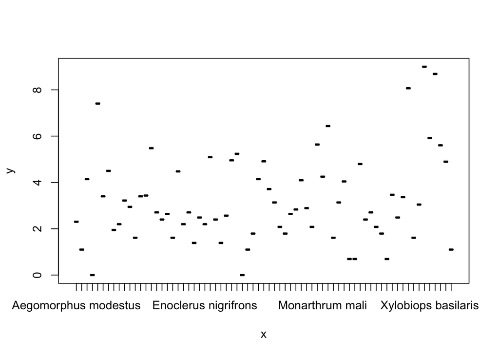

```r
# try to plot species abundance curve
ordered.data <- orderBy(~ -Total, new.data.frame)
plot(ordered.data$Species, log(ordered.data$Total)) ### thats not what we want
```

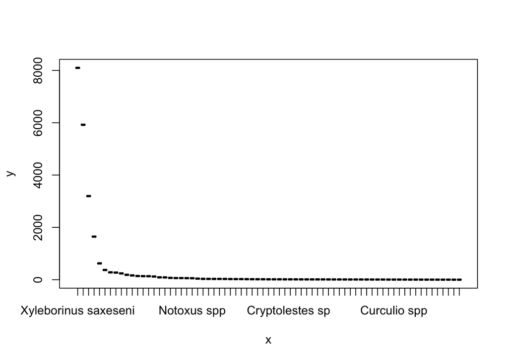

```r
# re order its levels with `factor(levels =)`
new.data.frame$Species <- factor(new.data.frame$Species, levels = orderBy(~ -Total, new.data.frame)$Species)
plot(new.data.frame$Species, new.data.frame$Total)
```

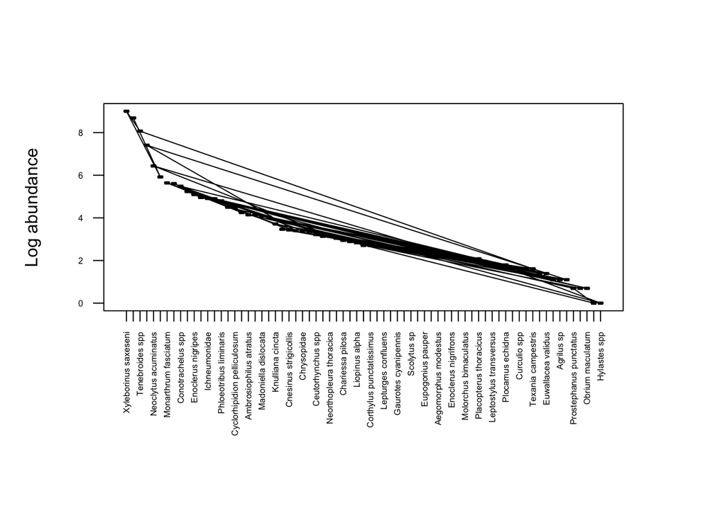

```r
# make the plot lineas instead of points
par(mar=c(10,5,5,5))
plot(new.data.frame$Species, log(new.data.frame$Total), las=2, ylab="Log abundance", xlab="", cex.axis=0.5)

# you can add a line to the existing plot with lines() which has the same
lines(new.data.frame$Species, log(new.data.frame$Total))
```

Note that even though the plot was plotted with the x axis in the correct order, the points are drawn in the order of the original data.frame. To get around this, we’ll also have to reorder the data.frame.

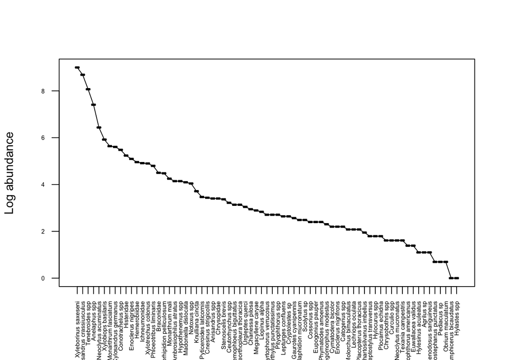

```r
# Run this command again to re-order the data frame, which now has the factor levels in the proper order
ordered.data <- orderBy(~ -Total, new.data.frame)
plot(ordered.data$Species, log(ordered.data$Total), las=2, ylab="Log abundance", xlab="", cex.axis=0.5)
lines(ordered.data$Species, log(ordered.data$Total))
```

## Excercise

> Start a new script with File > New File > R Script if you are in RStudio or File > New Document in R

> Plot the log mean +/- sd of the beetle species (in order) using the function `plot`
- Read in the original data
- Make a new column with mean + standard error
- Make a new column with mean - standard error
- Log-transform the three new columns
- Plot the log mean
- Add dotted lines in different colors (`?par`) for log mean +/- SE
- Add a legend with this code

```r
legend("topright", legend = c("Mean", "+/- SE"), lty=c(1,2), col=c("black","blue"))
```